# AGBRESA Spatial Cognition 2

A Stahn

10/27/2021

# Prepare Script

## Required Packages

```r
library(knitr) # for kable
library(readxl) # read xls
library(DT) # Print table nicely in markdown
library(reshape2) # wide to long
library(plyr) # ldply
library(tidyverse) # for fct_relevel

library(lme4) # for adding mixed model functions to plot
library(lmerTest) # for adding mixed model functions to plot
library(nlme)
library(emmeans) # for adding mixed model marignal means and se to plot
library(qdapTools) # list_df2df(tbl_mm_fac_aov)

library(ggpubr) # for compare means, descriptives and theme_pubr
library(ggplot2)
library(ggsci)
library(scales)
library(cowplot) # for plot_grid, combine plots using cowplot
```

## Themes for Plots

```r
# Correct ggplot2 pts and fonts
ggplot_factor_line <- ggplot2::.pt*72.27/96
ggplot_factor_font = 1.0

# Create project report theme
theme_report_white  <-  theme_pubr() + theme(
  axis.line = element_line(size = 0.5 / ggplot_factor_line,color="black"),
  axis.ticks = element_line(size = 0.5 / ggplot_factor_line, color="black"),
  axis.ticks.length = unit(0.2, "cm"),
  text = element_text(size = 8 * ggplot_factor_font,
                      family="Helvetica",
                      colour="black"),
  axis.text.x=element_text(angle = 0,
                           vjust = 0.5,
                           size = 8 * ggplot_factor_font,
                           family = "Helvetica",
                           colour = "black"), #face="bold"
  axis.text.y = element_text(angle = 0,
                            vjust=0.5,
                            size= 8 * ggplot_factor_font,
                            family = "Helvetica",
                            colour="black"),
  axis.title.x = element_text(angle = 0,
                            vjust =0.5,
                            size= 8 * ggplot_factor_font,
                            family="Helvetica",
                            colour="black",
                            face="bold"),
  axis.title.y = element_text(angle = 90,
                            vjust = 0.5,
                            size= 8 * ggplot_factor_font,
                            family = "Helvetica",
                            colour = "black",
                            face = "bold") # face = "bold"
  )

#color
#p.sut_desc <- p.sut_desc + scale_color_brewer(palette="Paired",limits = c("cAG", "iAG", "CTRL"), labels = c("cAG", "iAG", "CTRL"))+scale_fill_brewer(palette="Paired",limits = c("cAG", "iAG", "CTRL"), labels = c("cAG", "iAG", "CTRL"))
#p.sut <- p.sut + scale_colour_manual(values = c("black", "black", "black"), labels = c("cAG", "iAG", "CTRL"))+scale_fill_brewer(palette="Paired",limits = c("cAG", "iAG", "CTRL"), labels = c("cAG", "iAG", "CTRL"))
#p.sut_main <- p.sut_main + scale_color_brewer(palette="Paired",limits = c("cAG", "iAG", "CTRL"), labels = c("cAG", "iAG", "CTRL"))+scale_fill_brewer(palette="Paired",limits = c("cAG", "iAG", "CTRL"), labels = c("cAG", "iAG", "CTRL"))
```

## Load Data

```r
#  Demographics
df_demo <- read_excel("./Data/Data Demographics.xlsx", sheet = "Data Demo")
df_demo[c(1:5)] <- lapply(df_demo[c(1:5)], factor)

# Spatial Cognition performed before and after bed rest
# NAVIS VR
df_navis_vr <- read_excel("./Data/Data Spatial Cognition 1.xlsx", sheet = "Data NAVIS VR z")
df_navis_vr[c(1:3)] <- lapply(df_navis_vr[c(1:3)], as.factor)

# Spatial Cognition performed after bed rest
# SOT
df_sot <- read_excel("./Data/Data Spatial Cognition 2.xlsx", sheet = "Data SOT z")
df_sot[c(1:2)] <- lapply(df_sot[c(1:2)], as.factor)
df_sot[c(3:5)] <- lapply(df_sot[c(3:5)], as.numeric)

# Cognitive Mapping
df_cogmap <- read_excel("./Data/Data Spatial Cognition 2.xlsx", sheet = "Data Cognitive Mapping z")
df_cogmap[c(1:4)] <- lapply(df_cogmap[c(1:4)], as.factor)
df_cogmap[c(5:8)] <- lapply(df_cogmap[c(5:8)], as.numeric)
colnames(df_cogmap)[6] <- "acc_z"
colnames(df_cogmap)[7] <- "rt_z"
df_cogmap_agbresa <- subset(df_cogmap, group_2 != "CTRL_Amb" & group_2 != "R+180" )
df_cogmap_agbresa <- df_cogmap_agbresa[-c(2:5)]

# Water Maze
df_wm <- read_excel("./Data/Data Spatial Cognition 2.xlsx", sheet = "Data WM z")
df_wm[c(1:2)] <- lapply(df_wm[c(1:2)], as.factor)
df_wm[c(3:9)] <- lapply(df_wm[c(3:9)], as.numeric)
colnames(df_wm)[3] <- "rt_z"
colnames(df_wm)[4] <- "distance_z"
colnames(df_wm)[8] <- "heading_error_z"

# Plus Maze
df_pm <- read_excel("./Data/Data Spatial Cognition 2.xlsx", sheet = "Data PM z")
df_pm[c(1:2)] <- lapply(df_pm[c(1:2)], as.factor)
df_pm[c(3:ncol(df_pm))] <- lapply(df_pm[c(3:ncol(df_pm))], as.numeric)

# Navigation Strategy
df_navstrat <- read_excel("./Data/Data Spatial Cognition 2.xlsx", sheet = "Data Navstrat z")
df_navstrat[c(1:4)] <- lapply(df_navstrat[c(1:4)], as.factor)
df_navstrat[c(5:ncol(df_navstrat))] <- lapply(df_navstrat[c(5:ncol(df_navstrat))], as.numeric)

df_navstrat$direction <- factor(df_navstrat$direction,
levels = c("diff", "same"),
labels = c("Different", "Same"))
```

# Definition of Helper Functions

## Descriptive Functions

```r
# Function to check data completion
func_data_completion <- function(data, ...) {

  if(!"time.f" %in% names(data)) {
    data$time.f <- as.factor( c( rep(1, nrow(data) ) ) )
    }

  if(!"cond.f" %in% names(data)) {
    data$cond.f <- as.factor( c( rep(1, nrow(data) ) ) )
    }

  data <- reshape2::melt( data,
                              id.vars = names( Filter(is.factor, data) )
                              )  %>%

  group_by(variable) %>%
  dplyr::summarise(
      N = 24 * length( levels(time.f) ) * length( levels(cond.f) ),
      n = sum( !is.na(value) ),
      Percent = n / N * 100
      )
}

# Function to compute descriptives
func_desc <- function(data, ...) {
  df_tmp <- df_demo[ , !names(df_demo) %in% c("age","height", "weight")]
  data <- merge(df_tmp, data, by = "id") #add demo
  data <- reshape2::melt( data,
                              id.vars = names( Filter(is.factor, data) )
                              )
  groups <- enquos(...)

  result <- data %>%

    group_by(!!!groups) %>%

    dplyr::summarise(
      MEAN = mean(value, na.rm = T),
      SE = sd(value, na.rm = T) / sqrt(length(value) )
      )
  return(result)
}
```

## Plot Functions

```r
# Wrapper function for line plots, forwards to func_plot_line_facet
func_plot_line <- function(x) {ggplot(x, tmpaes_plot) +
    theme_report_white +
    geom_line(position = pd) +
    geom_errorbar(tmpaes_errorbar,
                  width =.4,
                  position = pd) +
    geom_point(position = pd,
               shape = 21,
               size = 2) + # shape = 21, size = 1, fill = "white"
    scale_y_continuous(expand = c(0,0)) +
    labs(y = "", x = "Time", size = 10) +
    theme(legend.title = element_blank(),
          legend.text = element_text(size = 8),
          axis.title.x = element_text(size = 10))
  }

# Function for line plots, takes 'desc' as input
func_plot_line_facet <- function(x) {func_plot_line(x) +
    facet_grid_def +
    theme(strip.placement = "outside",
          strip.background = element_rect(color = "transparent",
                                          fill = "transparent", size = 1.5,
                                          linetype = "solid"),
          strip.text = element_text(size = 10,
                                    color = "black",
                                    face = "bold"),
          panel.spacing.y = unit(2, "lines"))
}

# Wrapper function for bar plots, forwards to func_plot_bar_facet
func_plot_bar <- function(x) {ggplot(x, tmpaes_plot) + theme_report_white +
    geom_hline(yintercept = 0,
               size = 0.3,
               linetype = "solid") +
    geom_errorbar(tmpaes_errorbar,
                 width = .4,
                  position = pd,
                  color = "black") +
    geom_bar(tmpaes_geombar, # separate by category
             stat = "identity",
             position = pd,
             width = 1.0,
             color = "black") + # make it side-by-side
    scale_y_continuous(expand = c(0,0)) +
    labs(y = "", x = "", size = 10) +
    guides(x = "none") +
    theme(legend.title = element_blank(),
          legend.text = element_text(size=8),
          axis.title.x = element_text(size = 10),
          axis.text.x = element_blank(),
          axis.ticks.x = element_blank())
}

# Function for bar plots, takes 'desc' as input
func_plot_bar_facet <- function(x) {func_plot_bar(x) +
    facet_grid_def +
    theme(strip.placement = "outside",
          strip.background = element_rect(color = "transparent",
                                          fill = "transparent", size = 1.5,
                                          linetype = "solid"),
          strip.text = element_text(size = 10,
                                    color = "black",
                                    face = "bold"),
          panel.spacing.y = unit(2, "lines"))
}
```

## Functions for Mixed Models

```r
# Wrapper for appending bdc data as covariate
func_bdc_cov <- function(data, ...) {

  df_tmp <- subset(data, time.f != bdc)

  df_tmp_pre <- subset(data, time.f == bdc) %>%
    rename_at(vars(contains("_z")), ~ str_c("pre_", .)) %>%
    select("id" | is.numeric)

  df_tmp <- merge(df_tmp_pre, df_tmp, by = "id")
  droplevels(df_tmp)

  df_tmp <- merge(df_demo, df_tmp,by  = c("id"))
}

# nlme
# Wrapper for mixed models, takes 'dvList', requires 'model_mm', e.g., model_mm <- paste0(" + sex"," + age", " + time.f",  " * group_3", " * cond.f", " + (1|id)" )
func_mm_fac_help_nlme <- function(dvList) {
  map(dvList, function(i) {
    f <- formula(paste(i, pred, sep = "~"))
    mm <- lme(fixed = f,
              random = ~ 1 | id,
              data = df_tmp)
    mm$call$fixed <- f
    mm}) %>% setNames(dvList)
}

# Helper functions for creating mixed model tables, takes 'dvList'
func_tbl_aov_nlme <- function(x) {
  tbl_mm_fac_aov <- list_df2df(tbl_mm_fac_aov)
  names(tbl_mm_fac_aov)[2] <- "df1"
  names(tbl_mm_fac_aov)[3] <- "df2"
  names(tbl_mm_fac_aov)[4] <- "F"
  names(tbl_mm_fac_aov)[5] <- "P"
  tbl_mm_fac_aov[c(4)] <- round(tbl_mm_fac_aov[c(4)], digits = 2) # Round
  tbl_mm_fac_aov[c(5)] <- round(tbl_mm_fac_aov[c(5)], digits = 3) # Round
  return(tbl_mm_fac_aov)
}


# Helper function emmeans, takes 'dvList'; requires to define 'model', e.g., model <- c(~ time.f * group_3 * cond.f)
func_emm_fac_nlme <- function(x) {
  mm_fac <- func_mm_fac_help_nlme(dvList)
  emm_fac <- lapply(mm_fac, function(mm_fac) emmeans::emmeans(mm_fac, model_emmeans, lmer.df = "satterthwaite"))
  emm_fac_ <- lapply(emm_fac, data.frame)
  table_emm_fac_df <- ldply(emm_fac_, data.frame) #create df
  table_emm_fac_df_raw <- table_emm_fac_df
  table_emm_fac_df_raw$.id <- as.factor(as.character(table_emm_fac_df_raw$.id ))
  rm(emm_fac_)
  return(table_emm_fac_df_raw)
}

# Function for contrasts, requires 'func_mm_fac_help'
func_contrasts_emm_fac_nlme <- function(x) {
  mm_fac <- func_mm_fac_help_nlme(dvList)
  emm_fac <- lapply(mm_fac, function(mm_fac) emmeans::emmeans(mm_fac, model_emmeans, lmer.df = "satterthwaite"))
  contrasts_mm_fac <- lapply(emm_fac, function(emm_fac) contrast(emm_fac, contrast_type,
                                                                         by = factors,
                                                                         lmer.df = "satterthwaite",
                                                                         adjust="none"))
  contrasts_mm_fac <- lapply(contrasts_mm_fac, summary, infer = T) #add adj confidence intervals (adjusted if adjustment method is selected: https://cran.r-project.org/web/packages/emmeans/vignettes/confidence-intervals.html)
  contrasts_mm_fac_ <- lapply(contrasts_mm_fac, data.frame) #create df
  contrasts_mm_fac_df <- ldply(contrasts_mm_fac_, data.frame) #create df
  rm(contrasts_mm_fac_)
  return(contrasts_mm_fac_df)
}

# Helper function contrasts emmeans, takes 'dvList', and requires func_contrasts_emm_fac_nlme
func_tbl_contr_emm_fac_nlme <- function(dvList) {
  tmp <- func_contrasts_emm_fac_nlme(dvList)
  tmp[ncol(tmp)] <- round(tmp[ncol(tmp)], digits = 3) #round
  tmp[ncol(tmp)-1] <- round(tmp[ncol(tmp)-1], digits = 2) #round
  tmp[ncol(tmp)-2] <- round(tmp[ncol(tmp)-2], digits = 2) #round
  tmp[ncol(tmp)-3] <- round(tmp[ncol(tmp)-3], digits = 2) #round
  tmp[ncol(tmp)-4] <- round(tmp[ncol(tmp)-4], digits = 1) #round
  tmp[ncol(tmp)-5] <- round(tmp[ncol(tmp)-5], digits = 2) #round
  tmp[ncol(tmp)-6] <- round(tmp[ncol(tmp)-6], digits = 2) #round
  tmp$CI <- paste0("(",tmp$lower.CL,"," ,tmp$upper.CL,")")
  tmp$CI <- gsub( ",", ", ", tmp$CI )
  tmp$CI <- paste0(tmp$estimate," " ,tmp$CI)
  tmp <- tmp[-c(ncol(tmp)-3,
                ncol(tmp)-4,
                ncol(tmp)-6,
                ncol(tmp)-7)]
  colnames(tmp)[ncol(tmp)] <- "Mean (95%CI)"
  colnames(tmp)[ncol(tmp)-1] <- "P (unadjusted)"
  colnames(tmp)[ncol(tmp)-2] <- "t"
  colnames(tmp)[2] <- "Contrast"
  return(tmp)
}

# lmer
# Wrapper for mixed models, takes 'dvList', requires 'model_mm', e.g., model_mm <- paste0(" + sex"," + age", " + time.f",  " * group_3", " * cond.f", " + (1|id)" )
func_mm_fac_with_bdc_adj_help <- function(dvList) {
  map(dvList, function(i) {
    lmerTest::lmer(paste0(i, " ~ pre_", i, model_mm),
                   REML=T,
                   data = df_tmp)
   }) %>% setNames(dvList) #add dvList names
}

# Helper function emmeans, takes 'dvList'; requires to define 'model', e.g., model <- c(~ time.f * group_3 * cond.f)
func_emm_fac_with_bdc_adj <- function(x) {
  mm_fac <- func_mm_fac_with_bdc_adj_help(dvList)
  emm_fac <- lapply(mm_fac, function(mm_fac) emmeans::emmeans(mm_fac, model_emmeans, lmer.df = "satterthwaite"))
  emm_fac_ <- lapply(emm_fac, data.frame)
  table_emm_fac_df <- ldply(emm_fac_, data.frame) #create df
  table_emm_fac_df_raw <- table_emm_fac_df
  table_emm_fac_df_raw$.id <- as.factor(as.character(table_emm_fac_df_raw$.id ))
  rm(emm_fac_)
  return(table_emm_fac_df_raw)
}

func_tbl_aov <- function(x) {
  tbl_mm_fac_aov <- list_df2df(tbl_mm_fac_aov)
  names(tbl_mm_fac_aov)[4] <- "df1"
  names(tbl_mm_fac_aov)[5] <- "df2"
  names(tbl_mm_fac_aov)[6] <- "F"
  names(tbl_mm_fac_aov)[7] <- "P"
  tbl_mm_fac_aov[c(5:6)] <- round(tbl_mm_fac_aov[c(5:6)], digits = 2) # Round
  tbl_mm_fac_aov[c(7)] <- round(tbl_mm_fac_aov[c(7)], digits = 3) # Round
  return(tbl_mm_fac_aov)
}

# Function for contrasts, requires 'func_mm_fac_help'
func_contrasts_emm_fac <- function(x) {
  mm_fac <- func_mm_fac_with_bdc_adj_help(dvList)
  emm_fac <- lapply(mm_fac, function(mm_fac) emmeans::emmeans(mm_fac, model_emmeans, lmer.df = "satterthwaite"))
  contrasts_mm_fac <- lapply(emm_fac, function(emm_fac) contrast(emm_fac, contrast_type,
                                                                         by = factors,
                                                                         lmer.df = "satterthwaite",
                                                                         adjust="none"))
  contrasts_mm_fac <- lapply(contrasts_mm_fac, summary, infer=T) #add adj confidence intervals (adjusted if adjustment method is selected: https://cran.r-project.org/web/packages/emmeans/vignettes/confidence-intervals.html)
  contrasts_mm_fac_ <- lapply(contrasts_mm_fac, data.frame) #create df
  contrasts_mm_fac_df <- ldply(contrasts_mm_fac_, data.frame) #create df
  rm(contrasts_mm_fac_)
  return(contrasts_mm_fac_df)
}

# Function for contrast table; requires 'func_contrasts_emm_fac'
func_tbl_contr_emm_fac <- function(dvList) {
  tmp <- func_contrasts_emm_fac(dvList)
  tmp[ncol(tmp)] <- round(tmp[ncol(tmp)], digits = 3) #round
  tmp[ncol(tmp)-1] <- round(tmp[ncol(tmp)-1], digits = 2) #round
  tmp[ncol(tmp)-2] <- round(tmp[ncol(tmp)-2], digits = 2) #round
  tmp[ncol(tmp)-3] <- round(tmp[ncol(tmp)-3], digits = 2) #round
  tmp[ncol(tmp)-4] <- round(tmp[ncol(tmp)-4], digits = 1) #round
  tmp[ncol(tmp)-5] <- round(tmp[ncol(tmp)-5], digits = 2) #round
  tmp[ncol(tmp)-6] <- round(tmp[ncol(tmp)-6], digits = 2) #round
  tmp$CI <- paste0("(",tmp$lower.CL,"," ,tmp$upper.CL,")")
  tmp$CI <- gsub( ",", ", ", tmp$CI )
  tmp$CI <- paste0(tmp$estimate," " ,tmp$CI)
  tmp <- tmp[-c(ncol(tmp)-3,
                ncol(tmp)-4,
                ncol(tmp)-6,
                ncol(tmp)-7)]
  colnames(tmp)[ncol(tmp)] <- "Mean (95%CI)"
  colnames(tmp)[ncol(tmp)-1] <- "P (unadjusted)"
  colnames(tmp)[ncol(tmp)-2] <- "t"
  colnames(tmp)[2] <- "Contrast"
  return(tmp)
}
```

# Data Completion Check

```r
# Spatial Cognition performed after
# SOT # Note: n=8 not collected, requires correction of func_data_completion
missing_sot <- func_data_completion(df_sot)

# Cognitive Mapping
missing_cogmap <- func_data_completion(df_cogmap_agbresa)

# Navigation Strategy
missing_navstrat <- func_data_completion(df_navstrat)
missing_navstrat$n <- missing_navstrat$n/12 # correct for additional conditions: 2 dir x 6 blocks
missing_navstrat$Percent <- missing_navstrat$Percent/12 # correct for additional conditions: 2 dir x 6 blocks

# virtual Water Maze
missing_wm <- func_data_completion(df_wm)

# PM
missing_pm <- func_data_completion(df_pm)

# Spatial Cognition performed before & after
# NAVIS VR
missing_navis_vr <- func_data_completion(df_navis_vr)

# Combine summary
spat_bat_2_summary <- bind_rows(
                              missing_sot[1,],
                              missing_cogmap[1,],
                              missing_navstrat[1,],
                              missing_wm[1,],
                              missing_pm[1,],
                              missing_navis_vr[2,])  # note: Accuracy was 100%

spat_bat_2_summary$Task <- c("Spatial Orientation Task",
                           "Cognitive Mapping Task",
                           "Navigation Strategy Task",
                           "Water Maze Task",
                           "Plus Maze Task",
                           "Navigation Search Task VR")

spat_bat_2_summary <- spat_bat_2_summary[c(5,2:4)]
colnames(spat_bat_2_summary)[2] <- "Expected (N)"
colnames(spat_bat_2_summary)[3] <- "Completed (N)"
colnames(spat_bat_2_summary)[4] <- "Completed (%)"
spat_bat_2_summary <- as.data.frame(spat_bat_2_summary)
```

#### Table 1. Data collection summary Spatial Cognition 2.

|  | Task | Expected (N) | Completed (N) | Completed (%) |
| --- | --- | --- | --- | --- |
| 1 | Spatial Orientation Task | 24 | 16 | 66.6666666666667 |
| 2 | Cognitive Mapping Task | 24 | 24 | 100 |
| 3 | Navigation Strategy Task | 24 | 24 | 100 |
| 4 | Water Maze Task | 24 | 24 | 100 |
| 5 | Plus Maze Task | 24 | 24 | 100 |
| 6 | Navigation Search Task VR | 144 | 144 | 100 |

```
## [1] 94.4
```

# Spatial Orientation Task

## Mixed Model Comparing Groups

```r
# Compute desc
desc <- func_desc(df_sot, group_3, variable)

# Mixed Models
# Add groups
df_tmp <- merge(df_demo, df_sot, by = "id") #add demo

# Select dep vars
dvList <- c("rt_z", "pointing_error_z", "score_z")

# Select predictors
pred <- c("sex + age + group_3")

# Run mixed models
tbl_mm_fac_aov <- sapply(func_mm_fac_help_nlme(dvList), anova, simplify = FALSE, USE.NAMES = TRUE)

# ANOVA table
tbl_mm_fac_aov_df <- func_tbl_aov_nlme(dvList)
tbl_mm_fac_aov_df <- tbl_mm_fac_aov_df[-c(1, 5, 9),]

# Helper functions for parameter definition in mixed model tables, takes 'dvList'
Parameter_func <- function(dvList){
  rep(c(
  "Sex",
  "Age",
  "Group"),
                 length(dvList))
}

# Add variables
Parameter <- Parameter_func(dvList)
blanks <- rep("", length(Parameter) / length(dvList) - 1)
Variable <- c("Speed", blanks,"Accuracy", blanks, "Efficiency", blanks)
tbl_mm_fac_aov_df_sot <- cbind(Variable, Parameter, tbl_mm_fac_aov_df[c(2:5)])
```

#### Table 2. Mixed Model Summary for Spatial Orientation Task.

| Variable | Parameter | df1 | df2 | F | P |
| --- | --- | --- | --- | --- | --- |
| Speed | Sex | 1 | 11 | 10.16 | 0.009 |
|  | Age | 1 | 11 | 16.93 | 0.002 |
|  | Group | 2 | 11 | 3.01 | 0.091 |
| Accuracy | Sex | 1 | 11 | 5.8 | 0.035 |
|  | Age | 1 | 11 | 1.26 | 0.285 |
|  | Group | 2 | 11 | 1.05 | 0.383 |
| Efficiency | Sex | 1 | 11 | 14.55 | 0.003 |
|  | Age | 1 | 11 | 19.68 | 0.001 |
|  | Group | 2 | 11 | 3.05 | 0.089 |

## Contrasts for Group Comparisons

```r
# Contrasts
# Define model for contrasts
model_emmeans <- ~ group_3

# Define contrasts
contrast_type <- "pairwise"
factors <- c()

# Run contrasts
tbl_contr_emm_fac_df <- func_tbl_contr_emm_fac_nlme(dvList)

# Create vars to make nice table
tbl_contr_emm_fac_df$Variable <- c("Speed", rep("", 2),
                                   "Accuracy", rep("", 2),
                                   "Efficiency", rep("", 2))

# Table for contrasts
tbl_contr_emm_fac_df_sot <- tbl_contr_emm_fac_df[c(7, 2, 6, 3:5)]
```

#### Table 3. Mixed Model Group Contrasts for Spatial Orientation Task.

| Variable | Contrast | Mean (95%CI) | df | t | P (unadjusted) |
| --- | --- | --- | --- | --- | --- |
| Speed | cAG - CTRL | 0.95 (0.07, 1.82) | 11 | 2.38 | 0.036 |
|  | cAG - iAG | 0.25 (-0.64, 1.14) | 11 | 0.62 | 0.545 |
|  | CTRL - iAG | -0.7 (-1.6, 0.21) | 11 | -1.7 | 0.117 |
| Accuracy | cAG - CTRL | 0.79 (-0.63, 2.22) | 11 | 1.23 | 0.245 |
|  | cAG - iAG | -0.05 (-1.5, 1.39) | 11 | -0.08 | 0.937 |
|  | CTRL - iAG | -0.85 (-2.31, 0.61) | 11 | -1.28 | 0.228 |
| Efficiency | cAG - CTRL | 0.85 (0.02, 1.67) | 11 | 2.26 | 0.045 |
|  | cAG - iAG | 0.08 (-0.76, 0.92) | 11 | 0.21 | 0.836 |
|  | CTRL - iAG | -0.77 (-1.62, 0.08) | 11 | -1.99 | 0.072 |

## Plot Estimated Marignal Means for Group Comparisons

```r
# Run emmeans
emm_fac <- func_emm_fac_nlme(dvList) #requires mm_fac from nlme

# Define aes for func_plot
tmpaes_plot <- aes(x = group_3, y = emmean,
                   group = group_3,
                   fill = group_3,
                   color = group_3)

tmpaes_errorbar <- aes(x = group_3,
                    ymin = emmean-SE,
                    ymax = emmean+SE)

tmpaes_geombar <- aes(x = group_3,
                    y = emmean,
                    fill=group_3)

# New facet label names for variable
new_labels <- c("Speed","Accuracy","Efficiency")
names(new_labels) <- c("rt_z", "pointing_error_z","score_z")

# Define labels for func_plot_line_facet
labeller_def <- labeller(.id = new_labels)

facet_grid_def <- facet_grid(~ .id,
                             switch = "y",
                             labeller = labeller_def)
# Draw plot
pd <- position_dodge(0.1)
p.sot_emmeans <- func_plot_bar_facet(emm_fac %>%
                                       mutate(
                                         .id = fct_relevel(.id, "rt_z", "pointing_error_z", "score_z"),
                                         group_3 = fct_relevel(group_3, "CTRL", "cAG", "iAG")
                                         )
                                     )

# Adjust legend size
p.sot_emmeans <- p.sot_emmeans + theme(legend.key.size = unit(0.3, 'cm'))

# Save plot as pdf
pdf("./Figures/Spatial Cognition 2/p.sot_emmeans.pdf",
    width = 10/2.54,
    height = 8/2.54,
    useDingbats = FALSE) #in cm
print(p.sot_emmeans)
dev.off()
```

#### Figure 1. Spatial Orientation Task: Effects of Bed Rest on Speed, Accuracy, and Efficiency on HDT59. Data are means and SE.

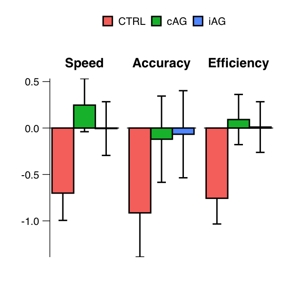

# Virtual Water Maze

## Mixed Model Comparing Groups

```r
# Compute desc
desc <- func_desc(df_wm, group_3, variable)

# Mixed Models
# Add groups
df_tmp <- merge(df_demo, df_wm, by = "id") #add demo

# Select dep vars
dvList <- c("rt_z", "distance_z", "heading_error_z")

# Select predictors
pred <- c("sex + age + group_3")

# Run mixed models
tbl_mm_fac_aov <- sapply(func_mm_fac_help_nlme(dvList), anova, simplify = FALSE, USE.NAMES = TRUE)

# ANOVA table
tbl_mm_fac_aov_df <- func_tbl_aov_nlme(dvList)

tbl_mm_fac_aov_df <- tbl_mm_fac_aov_df[-c(1, 5, 9),]

# Helper functions for parameter definition in mixed model tables, takes 'dvList'
Parameter_func <- function(dvList){
  rep(c(
  "Sex",
  "Age",
  "Group"),
                 length(dvList))
}

# Add variables
Parameter <- Parameter_func(dvList)
blanks <- rep("", length(Parameter) / length(dvList) - 1)
Variable <- c("Speed", blanks,"Pathlength", blanks, "Heading Error", blanks)
tbl_mm_fac_aov_df_wm <- cbind(Variable, Parameter, tbl_mm_fac_aov_df[c(2:5)])
```

#### Table 4. Mixed Model Summary for virtual Water Maze Task.

| Variable | Parameter | df1 | df2 | F | P |
| --- | --- | --- | --- | --- | --- |
| Speed | Sex | 1 | 19 | 1.46 | 0.241 |
|  | Age | 1 | 19 | 0.15 | 0.699 |
|  | Group | 2 | 19 | 3.99 | 0.036 |
| Pathlength | Sex | 1 | 19 | 1.74 | 0.203 |
|  | Age | 1 | 19 | 7.02 | 0.016 |
|  | Group | 2 | 19 | 0.67 | 0.524 |
| Heading Error | Sex | 1 | 19 | 2.37 | 0.14 |
|  | Age | 1 | 19 | 1.44 | 0.245 |
|  | Group | 2 | 19 | 0.32 | 0.728 |

## Contrasts for Group Comparisons

```r
# Contrasts
# Define model for contrasts
model_emmeans <- ~ group_3

# Define contrasts
contrast_type <- "pairwise"
factors <- c()

# Run contrasts
tbl_contr_emm_fac_df <- func_tbl_contr_emm_fac_nlme(dvList)

# Create vars to make nice table
tbl_contr_emm_fac_df$Variable <- c("Speed", rep("", 2),
                                   "Pathlength", rep("", 2),
                                   "Heading Error", rep("", 2))

# Table for contrasts
tbl_contr_emm_fac_df_wm <- tbl_contr_emm_fac_df[c(7, 2, 6, 3:5)]
```

#### Table 5. Mixed Model Group Contrasts for virtual Water Maze Task.

| Variable | Contrast | Mean (95%CI) | df | t | P (unadjusted) |
| --- | --- | --- | --- | --- | --- |
| Speed | cAG - CTRL | -1.28 (-2.23, -0.33) | 19 | -2.83 | 0.011 |
|  | cAG - iAG | -0.64 (-1.58, 0.31) | 19 | -1.41 | 0.174 |
|  | CTRL - iAG | 0.65 (-0.3, 1.59) | 19 | 1.43 | 0.168 |
| Pathlength | cAG - CTRL | -0.49 (-1.43, 0.45) | 19 | -1.08 | 0.292 |
|  | cAG - iAG | -0.09 (-1.02, 0.85) | 19 | -0.19 | 0.848 |
|  | CTRL - iAG | 0.4 (-0.53, 1.34) | 19 | 0.9 | 0.381 |
| Heading Error | cAG - CTRL | 0.29 (-0.76, 1.34) | 19 | 0.58 | 0.566 |
|  | cAG - iAG | -0.09 (-1.13, 0.95) | 19 | -0.19 | 0.855 |
|  | CTRL - iAG | -0.38 (-1.43, 0.66) | 19 | -0.77 | 0.449 |

## Plot Estimated Marignal Means for Group Comparisons

```r
# Run emmeans
emm_fac <- func_emm_fac_nlme(dvList) # requires mm_fac from nlme

# Define aes for func_plot
tmpaes_plot <- aes(x = group_3, y = emmean,
                   group = group_3,
                   fill = group_3,
                   color = group_3)

tmpaes_errorbar <- aes(x = group_3,
                    ymin = emmean-SE,
                    ymax = emmean+SE)

tmpaes_geombar <- aes(x = group_3,
                    y = emmean,
                    fill=group_3)

# New facet label names for variable
new_labels <- c("Speed","Pathlength","Heading Error")
names(new_labels) <- c("rt_z", "distance_z", "heading_error_z")

# Define labels for func_plot_line_facet
labeller_def <- labeller(.id = new_labels)

facet_grid_def <- facet_grid(~ .id,
                             switch = "y",
                             labeller = labeller_def)
# Draw plot
pd <- position_dodge(0.1)
p.wm_emmeans <- func_plot_bar_facet(emm_fac %>% mutate(.id = fct_relevel(.id, "rt_z", "heading_error_z", "distance_z"),
                                                       group_3 = fct_relevel(group_3, "CTRL", "cAG", "iAG")
                                                       )
                                    )

# Adjust legend size
p.wm_emmeans <- p.wm_emmeans + theme(legend.key.size = unit(0.3, 'cm'))

# Save plot as pdf
pdf("./Figures/Spatial Cognition 2/p.wm_emmeans.pdf",
    width = 10/2.54,
    height = 8/2.54,
    useDingbats = FALSE) #in cm
print(p.wm_emmeans)
dev.off()
```

#### Figure 2. Virtual Water Maze Task: Effects of bed rest on pathlength, heading error, and speed on HDT60. Data are means and SE.

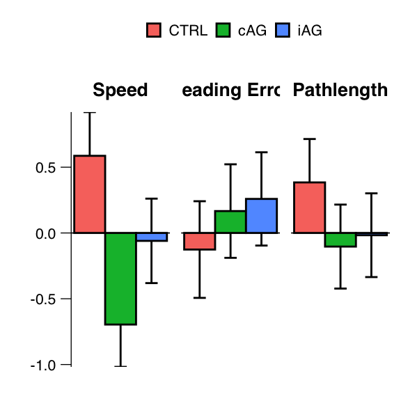

# Navigation Strategies Task

## Descriptive by block

```r
# Compute desc
desc <- func_desc(df_navstrat, group_3, variable, block, direction)

# Drop vars
desc <- subset(desc, variable != "incorrects_z")

# Plot desc
# Define aes for func_plot
tmpaes_plot <- aes(x = block, y = MEAN,
                   group = group_3,
                   fill = group_3,
                   color = group_3)

tmpaes_errorbar <- aes(x = block,
                    ymin = MEAN-SE,
                    ymax = MEAN+SE)

# New facet label names for variable
new_labels <- c("Speed","Accuracy","Efficiency")
names(new_labels) <- c("rt_z", "accuracy_z","eff_z")

new_labels2 <- c("Different Direction", "Same Direction")
names(new_labels2) <- c("Different", "Same")

# Define labels for func_plot_line_facet
labeller_def <- labeller(variable = new_labels,
                         direction = new_labels2)

facet_grid_def <- facet_grid(variable ~ direction,
                             switch = "y",
                             labeller = labeller_def)
# Draw plot
pd <- position_dodge(0.1)
p.navstrat_desc <- func_plot_line_facet(desc %>%
                                            mutate(variable = fct_relevel(variable, "rt_z", "accuracy_z", "eff_z"),
                                                   group_3 = fct_relevel(group_3, "CTRL", "cAG", "iAG")))

# Adjust legend size
p.navstrat_desc <- p.navstrat_desc + theme(legend.key.size = unit(0.3, 'cm'))
```

## Mixed Model Comparing Groups

```r
# Mixed Models
# Add groups
df_tmp <- merge(df_demo, df_navstrat, by = "id") #add demo

# Select dep vars
dvList <- c("rt_z", "accuracy_z", "eff_z")

# Select predictors
pred <- c("sex + age + block * group_3 * direction")

# Run mixed models
tbl_mm_fac_aov <- sapply(func_mm_fac_help_nlme(dvList), anova, simplify = FALSE, USE.NAMES = TRUE)

# ANOVA table
tbl_mm_fac_aov_df <- func_tbl_aov_nlme(dvList)

tbl_mm_fac_aov_df <- tbl_mm_fac_aov_df[-c(1, 5, 9),]

# helper functions for parameter definition in mixed model tables, takes 'dvList'
Parameter_func <- function(dvList){
  rep(c(
  "Sex",
  "Age",
  "Block",
  "Group",
  "Direction",
  "Block x Group",
  "Block x Direction",
  "Group x Direction",
  "Block x Group x Direction"),
                 length(dvList))
}

# Add variables
Parameter <- Parameter_func(dvList)
blanks <- rep("", length(Parameter) / length(dvList) - 1)
Variable <- c("Speed", blanks,"Accuracy", blanks, "Efficiency", blanks)
tbl_mm_fac_aov_df_navstrat <- cbind(Variable, Parameter, tbl_mm_fac_aov_df[c(3:5)])
```

#### Table 6. Mixed Model Summary for Navigation Strategies Task.

[output not shown]

[output cut: 17 more lines]

## Contrasts for Group Comparisons

```r
# Run Interaction Contrasts for Trends
mm_fac <- func_mm_fac_help_nlme(dvList)

contrasts_mm_fac <- lapply(mm_fac, function(mm_fac)
  contrast(emmeans(mm_fac, ~ block * group_3 | direction),
           interaction = c("poly", "consec"),
           lmer.df = "satterthwaite",
           adjust="none")
  )
# Add 95% CI
contrasts_mm_fac <- lapply(contrasts_mm_fac, summary, infer = T) #add adj confidence intervals (adjusted if adjustment method is selected: https://cran.r-project.org/web/packages/emmeans/vignettes/confidence-intervals.html)
contrasts_mm_fac_ <- lapply(contrasts_mm_fac, data.frame) #create df
contrasts_mm_fac_df <- ldply(contrasts_mm_fac_, data.frame) #create df
rm(contrasts_mm_fac_)

# Clean
tmp <- contrasts_mm_fac_df
tmp[c(5:9)] <- round(tmp[c(5:9)], 1)
tmp[c(10)] <- round(tmp[c(10)], 2)
tmp[c(11)] <- round(tmp[c(11)], 3)
tmp$CI <- paste0("(",tmp$lower.CL,"," ,tmp$upper.CL,")")
tmp$CI <- gsub( ",", ", ", tmp$CI )
tmp$CI <- paste0(tmp$estimate," " ,tmp$CI)
colnames(tmp)[ncol(tmp)] <- "Mean (95%CI)"
colnames(tmp)[ncol(tmp)-1] <- "P (unadjusted)"
colnames(tmp)[ncol(tmp)-2] <- "t"
colnames(tmp)[2] <- "Trend"
colnames(tmp)[3] <- "Contrast"
colnames(tmp)[4] <- "Direction"

tbl_contr_emm_fac_df <- tmp[c(2:4,12,7,10,11)]

# Create vars to make nice table
tbl_contr_emm_fac_df$Variable <- c("Speed", rep("", 19),
                                   "Accuracy", rep("", 19),
                                   "Efficency", rep("", 19))

# Table for contrasts
tbl_contr_emm_fac_df_navstrat <- tbl_contr_emm_fac_df[c(8, 1:7)]
```

#### Table 7. Mixed Model Group Contrasts for Navigation Strategies Task.

| Variable | Trend | Contrast | Direction | Mean (95%CI) | df | t | P (unadjusted) |
| --- | --- | --- | --- | --- | --- | --- | --- |
| Speed | linear | CTRL - cAG | Different | -6.8 (-12.2, -1.4) | 231 | -2.46 | 0.015 |
|  | quadratic | CTRL - cAG | Different | -0.5 (-6.4, 5.5) | 231 | -0.15 | 0.881 |
|  | cubic | CTRL - cAG | Different | 1.5 (-7.2, 10.2) | 231 | 0.34 | 0.738 |
|  | quartic | CTRL - cAG | Different | 1.2 (-2.2, 4.7) | 231 | 0.72 | 0.475 |
|  | degree 5 | CTRL - cAG | Different | -4.9 (-15.2, 5.4) | 231 | -0.94 | 0.35 |
|  | linear | iAG - CTRL | Different | 1.8 (-3.6, 7.3) | 231 | 0.67 | 0.503 |
|  | quadratic | iAG - CTRL | Different | 1.2 (-4.7, 7.2) | 231 | 0.41 | 0.686 |
|  | cubic | iAG - CTRL | Different | -2.3 (-11, 6.4) | 231 | -0.52 | 0.601 |
|  | quartic | iAG - CTRL | Different | 0.8 (-2.7, 4.2) | 231 | 0.45 | 0.656 |
|  | degree 5 | iAG - CTRL | Different | -2.5 (-12.8, 7.8) | 231 | -0.49 | 0.627 |

[output cut: 50 more lines]

## Plot Estimated Marignal Means for Group Comparisons

```r
# Run emmeans
model_emmeans <- ~ block * group_3 | direction
emm_fac <- func_emm_fac_nlme(dvList)

# Define aes for func_plot
tmpaes_plot <- aes(x = block, y = emmean,
                   group = group_3,
                   fill = group_3,
                   color = group_3)

tmpaes_errorbar <- aes(x = block,
                    ymin = emmean-SE,
                    ymax = emmean+SE)

# New facet label names for variable
new_labels <- c("Speed","Accuracy", "Efficiency")
names(new_labels) <- c("rt_z", "accuracy_z", "eff_z")

new_labels2 <- c("Same Direction","Different Direction")
names(new_labels2) <- c("Same", "Different")

# Define labels for func_plot_line_facet
labeller_def <- labeller(.id = new_labels,
                                   direction = new_labels2)

facet_grid_def <- facet_grid(.id ~ direction,
                             switch = "y",
                             labeller = labeller_def)

# Draw plot
pd <- position_dodge(0.4)
p.navstrat_emmeans <- func_plot_line_facet(emm_fac %>%
                                            mutate(.id = fct_relevel(.id, "rt_z", "accuracy_z", "eff_z"),
                                              group_3 = fct_relevel(group_3, "CTRL", "cAG", "iAG")
                                              )
                                           )

# Adjust legend size
p.navstrat_emmeans <- p.navstrat_emmeans + theme(legend.key.size = unit(0.3, 'cm'))

# Change axis title
p.navstrat_emmeans <- p.navstrat_emmeans + labs(y = "", x = "Block", size = 10)

# Save plot as pdf
pdf("./Figures/Spatial Cognition 2/p.navstrat_emmeans.pdf",
    width = 8/2.54,
    height = 18/2.54,
    useDingbats = FALSE) #in cm
print(p.navstrat_emmeans)
dev.off()
```

#### Figure 3. Navigation Strategies Task: Effects of bed rest on speed, accuracy, and efficiency on HDT60. Data are means and SE.

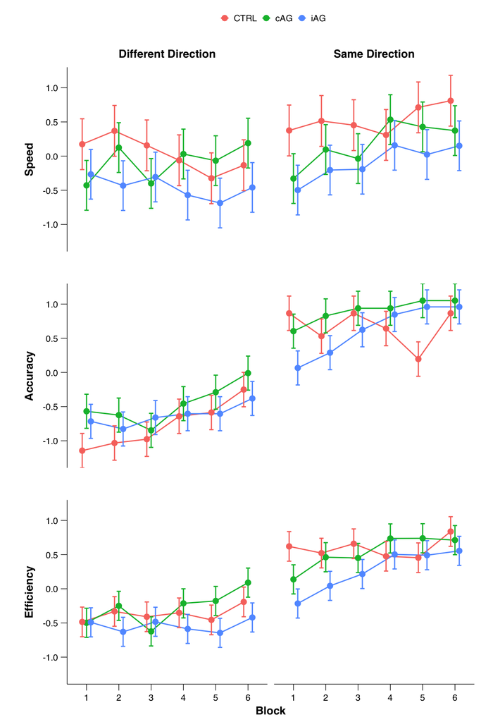

# Cognitive Mapping Task

## Mixed Model Comparing Groups

```r
# Compute desc
desc <- func_desc(df_cogmap_agbresa, group_3, variable)

# Mixed Models
# Add groups
df_tmp <- merge(df_demo, df_cogmap_agbresa, by = "id") #add demo

# Select dep vars
dvList <- c("rt_z", "acc_z", "eff_z")

# Select predictors
pred <- c("sex + age + group_3")

# Run mixed models
tbl_mm_fac_aov <- sapply(func_mm_fac_help_nlme(dvList), anova, simplify = FALSE, USE.NAMES = TRUE)

# ANOVA table
tbl_mm_fac_aov_df <- func_tbl_aov_nlme(dvList)
tbl_mm_fac_aov_df <- tbl_mm_fac_aov_df[-c(1, 5, 9),]

# Helper functions for parameter definition in mixed model tables, takes 'dvList'
Parameter_func <- function(dvList){
  rep(c(
  "Sex",
  "Age",
  "Group"),
                 length(dvList))
}

# Add variables
Parameter <- Parameter_func(dvList)
blanks <- rep("", length(Parameter) / length(dvList) - 1)
Variable <- c("Speed", blanks,"Accuracy", blanks, "Efficiency", blanks)
tbl_mm_fac_aov_df_cogmap <- cbind(Variable, Parameter, tbl_mm_fac_aov_df[c(3:5)])
```

#### Table 8. Mixed Model Summary for Cognitive Mapping Task.

| Variable | Parameter | df2 | F | P |
| --- | --- | --- | --- | --- |
| Speed | Sex | 19 | 0.24 | 0.632 |
|  | Age | 19 | 1.22 | 0.282 |
|  | Group | 19 | 1.15 | 0.338 |
| Accuracy | Sex | 19 | 3.31 | 0.085 |
|  | Age | 19 | 0.5 | 0.487 |
|  | Group | 19 | 1.15 | 0.337 |
| Efficiency | Sex | 19 | 2.75 | 0.114 |
|  | Age | 19 | 1.72 | 0.206 |
|  | Group | 19 | 1.04 | 0.373 |

## Contrasts for Group Comparisons

```r
# Contrasts
# Define model for contrasts
model_emmeans <- ~ group_3

# Define contrasts
contrast_type <- "pairwise"
factors <- c()

# Run contrasts
tbl_contr_emm_fac_df <- func_tbl_contr_emm_fac_nlme(dvList)

# Create vars to make nice table
tbl_contr_emm_fac_df$Variable <- c("Speed", rep("", 2),
                                   "Accuracy", rep("", 2),
                                   "Efficiency", rep("", 2))

# Table for contrasts
tbl_contr_emm_fac_df_cogmap <- tbl_contr_emm_fac_df[c(7, 2, 6, 3:5)]
```

#### Table 9. Mixed Model Group Contrasts for Cognitive Mapping Task.

| Variable | Contrast | Mean (95%CI) | df | t | P (unadjusted) |
| --- | --- | --- | --- | --- | --- |
| Speed | cAG - CTRL | -0.18 (-1.32, 0.96) | 19 | -0.33 | 0.744 |
|  | cAG - iAG | 0.6 (-0.53, 1.73) | 19 | 1.11 | 0.279 |
|  | CTRL - iAG | 0.78 (-0.35, 1.92) | 19 | 1.44 | 0.165 |
| Accuracy | cAG - CTRL | 0.82 (-0.31, 1.95) | 19 | 1.51 | 0.147 |
|  | cAG - iAG | 0.47 (-0.65, 1.59) | 19 | 0.88 | 0.392 |
|  | CTRL - iAG | -0.35 (-1.48, 0.78) | 19 | -0.65 | 0.525 |
| Efficiency | cAG - CTRL | 0.32 (-0.47, 1.11) | 19 | 0.85 | 0.408 |
|  | cAG - iAG | 0.54 (-0.25, 1.32) | 19 | 1.43 | 0.168 |
|  | CTRL - iAG | 0.22 (-0.57, 1) | 19 | 0.58 | 0.569 |

## Plot Estimated Marignal Means for Group Comparisons

```r
# Run emmeans
emm_fac <- func_emm_fac_nlme(dvList) #requires mm_fac from nlme

# New facet label names for variable
new_labels <- c("Speed","Accuracy","Efficiency")
names(new_labels) <- c("rt_z", "acc_z", "eff_z")

# Define aes for func_plot
tmpaes_plot <- aes(x = group_3, y = emmean,
                   group = group_3,
                   fill = group_3,
                   color = group_3)

tmpaes_errorbar <- aes(x = group_3,
                    ymin = emmean-SE,
                    ymax = emmean+SE)

tmpaes_geombar <- aes(x = group_3,
                    y = emmean,
                    fill=group_3)

# Define labels for func_plot_line_facet
labeller_def <- labeller(.id = new_labels)

facet_grid_def <- facet_grid(~ .id,
                             switch = "y",
                             labeller = labeller_def)
# Draw plot
pd <- position_dodge(0.1)
p.cogmap_emmeans <- func_plot_bar_facet(emm_fac %>%
                                          mutate(.id = fct_relevel(.id, "rt_z", "acc_z", "eff_z"),
                                                        group_3 = fct_relevel(group_3, "CTRL", "cAG", "iAG")
                                                        )
                                                 )

# Adjust legend size
p.cogmap_emmeans <- p.cogmap_emmeans + theme(legend.key.size = unit(0.3, 'cm'))

# Save plot as pdf
pdf("./Figures/Spatial Cognition 2/p.cogmap_emmeans.pdf",
    width = 10/2.54,
    height = 8/2.54,
    useDingbats = FALSE) #in cm
print(p.cogmap_emmeans)
dev.off()
```

#### Figure 4. Cognitive Mapping Task: Effect of bed rest on speed, accuracy, and efficiency on HDT59. Data are means and SE.

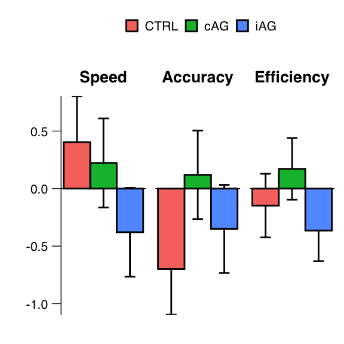

# Plus Maze Task

## Mixed Model Comparing Groups

```r
# Compute desc
desc <- func_desc(df_pm, group_3, variable)

# Mixed Models
# Add groups
df_tmp <- merge(df_demo, df_pm, by = "id") #add demo

# Select dep vars
dvList <- c("place_cor_z", "response_cor_z", "switch_cor_z", "reversal_cor_z", "switchtoplace_cor_z", "switchtoresponse_cor_z")

# Select predictors
pred <- c("sex + age + group_3")

# Run mixed models
tbl_mm_fac_aov <- sapply(func_mm_fac_help_nlme(dvList), anova, simplify = FALSE, USE.NAMES = TRUE)

# ANOVA table
tbl_mm_fac_aov_df <- func_tbl_aov_nlme(dvList)
tbl_mm_fac_aov_df <- tbl_mm_fac_aov_df[-c(1, 5, 9, 13, 17, 21),]

# Helper functions for parameter definition in mixed model tables, takes 'dvList'
Parameter_func <- function(dvList){
  rep(c(
  "Sex",
  "Age",
  "Group"),
                 length(dvList))
}

# Add variables
Parameter <- Parameter_func(dvList)
blanks <- rep("", length(Parameter) / length(dvList) - 1)
Variable <- c("Place Strategy", blanks,"Response Strategy", blanks, "Switch", blanks, "Reversal", blanks, "S2P", blanks, "S2R", blanks)
tbl_mm_fac_aov_df_pm <- cbind(Variable, Parameter, tbl_mm_fac_aov_df[c(2:5)])
```

#### Table 10. Mixed Model Summary for virtual Plus Maze Task.

| Variable | Parameter | df1 | df2 | F | P |
| --- | --- | --- | --- | --- | --- |
| Place Strategy | Sex | 1 | 19 | 0.96 | 0.339 |
|  | Age | 1 | 19 | 7.34 | 0.014 |
|  | Group | 2 | 19 | 0.43 | 0.654 |
| Response Strategy | Sex | 1 | 19 | 0.7 | 0.415 |
|  | Age | 1 | 19 | 3.89 | 0.063 |
|  | Group | 2 | 19 | 0.25 | 0.784 |
| Switch | Sex | 1 | 19 | 1.9 | 0.185 |
|  | Age | 1 | 19 | 5.31 | 0.033 |
|  | Group | 2 | 19 | 0.01 | 0.986 |
| Reversal | Sex | 1 | 19 | 2.94 | 0.103 |

[output cut: 8 more lines]

## Contrasts for Group Comparisons

```r
# Contrasts
# Define model for contrasts
model_emmeans <- ~ group_3

# Define contrasts
contrast_type <- "pairwise"
factors <- c()

# Run contrasts
tbl_contr_emm_fac_df <- func_tbl_contr_emm_fac_nlme(dvList)

# Create vars to make nice table
tbl_contr_emm_fac_df$Variable <- c("Place Strategy", rep("", 2),
                                   "Response Strategy", rep("", 2),
                                   "Switch", rep("", 2),
                                   "Reversal", rep("", 2),
                                   "S2P", rep("", 2),
                                   "S2R", rep("", 2))

# Table for contrasts
tbl_contr_emm_fac_df_sot <- tbl_contr_emm_fac_df[c(7, 2, 6, 3:5)]
```

#### Table 11. Mixed Model Group Contrasts for virtual Plus Maze Task.

| Variable | Contrast | Mean (95%CI) | df | t | P (unadjusted) |
| --- | --- | --- | --- | --- | --- |
| Place Strategy | cAG - CTRL | 0.38 (-0.59, 1.35) | 19 | 0.82 | 0.423 |
|  | cAG - iAG | 0.01 (-0.95, 0.98) | 19 | 0.03 | 0.98 |
|  | CTRL - iAG | -0.37 (-1.34, 0.6) | 19 | -0.8 | 0.435 |
| Response Strategy | cAG - CTRL | -0.27 (-1.21, 0.67) | 19 | -0.6 | 0.558 |
|  | cAG - iAG | 0.01 (-0.92, 0.94) | 19 | 0.02 | 0.984 |
|  | CTRL - iAG | 0.28 (-0.66, 1.21) | 19 | 0.62 | 0.542 |
| Switch | cAG - CTRL | 0.04 (-0.86, 0.94) | 19 | 0.1 | 0.922 |
|  | cAG - iAG | -0.03 (-0.92, 0.87) | 19 | -0.06 | 0.949 |
|  | CTRL - iAG | -0.07 (-0.97, 0.83) | 19 | -0.16 | 0.871 |
| Reversal | cAG - CTRL | -0.2 (-1.24, 0.83) | 19 | -0.42 | 0.683 |

[output cut: 8 more lines]

## Plot Estimated Marignal Means for Group Comparisons

```r
# Run emmeans
emm_fac <- func_emm_fac_nlme(dvList) #requires mm_fac from nlme

# New facet label names for variable
new_labels <- c("Place Strategy", "Response Strategy", "Switch", "Reversal", "S2P", "S2R")
names(new_labels) <- c("place_cor_z", "response_cor_z", "switch_cor_z", "reversal_cor_z", "switchtoplace_cor_z", "switchtoresponse_cor_z")

# Define aes for func_plot
tmpaes_plot <- aes(x = group_3, y = emmean,
                   group = group_3,
                   fill = group_3,
                   color = group_3)

tmpaes_errorbar <- aes(x = group_3,
                    ymin = emmean-SE,
                    ymax = emmean+SE)

tmpaes_geombar <- aes(x = group_3,
                    y = emmean,
                    fill=group_3)

# Define labels for func_plot_line_facet
labeller_def <- labeller(.id = new_labels)

facet_grid_def <- facet_wrap(~ .id,
                             switch = "y",
                             labeller = labeller_def,
                             ncol = 2)

facet_grid_def <- facet_wrap(~ .id,
                             labeller = labeller_def,
                             nrow = 2)

# Draw plot
pd <- position_dodge(0.1)
p.pm_emmeans <- func_plot_bar_facet(emm_fac %>%
                                      mutate(.id = fct_relevel(.id, "place_cor_z", "response_cor_z", "switch_cor_z", "reversal_cor_z", "switchtoplace_cor_z", "switchtoresponse_cor_z"),
                                         group_3 = fct_relevel(group_3, "CTRL", "cAG", "iAG")
                                         )
                                    )

# Adjust legend size
p.pm_emmeans <- p.pm_emmeans + theme(legend.key.size = unit(0.3, 'cm'))

# Save plot as pdf
pdf("./Figures/Spatial Cognition 2/p.pm_emmeans.pdf",
    width = 10/2.54,
    height = 6/2.54,
    useDingbats = FALSE) #in cm
print(p.pm_emmeans)
dev.off()
```

#### Figure 5. Plus Maze Task: Effect of bed rest on lace Strategy, Response Strategy, Switch, Reversal, Switch to Place (S2P), Switch to Response (S2R) on R+1. Data are means and SE.

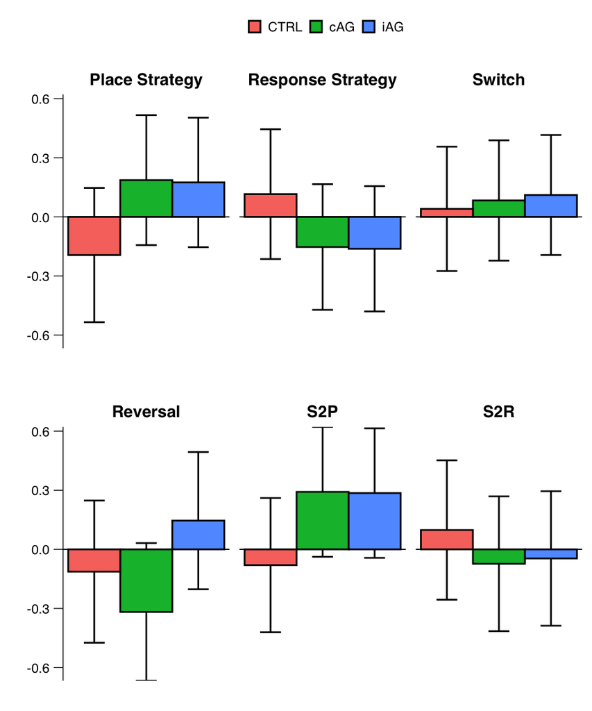

# Navigation Search VR

## Plot Time Course adjusted for Baseline

```r
# Compute desc
desc <- func_desc(df_navis_vr, group_3, cond.f, time.f, variable)

# Drop vars
desc <- subset(desc, variable != "acc_z" & variable != "time_to_first_revisit_z" & variable != "eff_acc_z" & variable != "eff_totdistance_z" & variable != "eff_totrevists_z")

# Plot desc
# New facet label names for variable
new_labels <- c("Speed","Distance","Revisits")
names(new_labels) <- c("rt_z","total_distance_z","total_revisits_z")

new_labels2 <- c("Day", "Night")
names(new_labels2) <- c("Day", "Night")

# Define aes for func_plot
tmpaes_plot <- aes(x = time.f, y = MEAN,
                   group = group_3,
                   fill = group_3,
                   color = group_3)

tmpaes_errorbar <- aes(x = time.f,
                    ymin = MEAN-SE,
                    ymax = MEAN+SE)

# Define labels for func_plot_line_facet
labeller_def <- labeller(variable = new_labels,
                                   cond.f = new_labels2)

facet_grid_def <- facet_grid(variable ~ cond.f,
                             switch = "y",
                             labeller = labeller_def)

# Draw plot
pd <- position_dodge(0.3)
p.navis_vr_desc <- func_plot_line_facet(desc %>%
                                          mutate(variable = fct_relevel(variable, "rt_z", "total_distance_z", "total_revisits_z"),
                                            group_3 = fct_relevel(group_3, "CTRL", "cAG", "iAG")
                                            )
                                        ) +
  geom_hline(yintercept = 0, size = 0.3, linetype = "dotted")

# Adjust legend size
p.navis_vr_desc <- p.navis_vr_desc + theme(legend.key.size = unit(0.3, 'cm'))
```

## Mixed Model for Group x Time Interaction

```r
# Mixed Models
# Add baseline as cov
bdc <- "BDC-6"
df_tmp <-  func_bdc_cov(df_navis_vr)

# Select dep vars
dvList <- c("rt_z","total_distance_z","total_revisits_z")

# Define model
model_mm <- paste0(" + sex"," + age", " + time.f", "* group_3", " * cond.f", " + (1|id)" )

# Run mixed models
tbl_mm_fac_aov <- sapply(func_mm_fac_with_bdc_adj_help(dvList), anova, simplify = FALSE, USE.NAMES = TRUE)

# ANOVA table
tbl_mm_fac_aov_df <- func_tbl_aov(dvList)

# Helper functions for parameter definition in mixed model tables, takes 'dvList'
Parameter_func <- function(dvList){
  rep(c(
  "Baseline",
  "Sex",
  "Age",
  "Time",
  "Group",
  "Task Condition",
  "Time x Group",
  "Time x Task Condition",
  "Group x Task Condition",
  "Time x Group x Task Condition"),
                 length(dvList))
}

# Add variables
Parameter <- Parameter_func(dvList)
blanks <- rep("", length(Parameter) / length(dvList) - 1)
Variable <- c("Speed", blanks, "Distance", blanks, "Revisits", blanks)
tbl_mm_fac_aov_df_navis_vr <- cbind(Variable, Parameter, tbl_mm_fac_aov_df[c(4:7)])
```

#### Table 12. Mixed Model Summary for Navigation Search Task VR.

| Variable | Parameter | df1 | df2 | F | P |
| --- | --- | --- | --- | --- | --- |
| Speed | Baseline | 1 | 175.43 | 0.07 | 0.793 |
|  | Sex | 1 | 18.92 | 0.16 | 0.691 |
|  | Age | 1 | 19.91 | 0.05 | 0.828 |
|  | Time | 1 | 158.15 | 1.29 | 0.258 |
|  | Group | 2 | 19.03 | 0.91 | 0.418 |
|  | Task Condition | 1 | 158.15 | 7.97 | 0.005 |
|  | Time x Group | 2 | 158.15 | 1.98 | 0.141 |
|  | Time x Task Condition | 1 | 158.15 | 0.31 | 0.58 |
|  | Group x Task Condition | 2 | 158.15 | 4.81 | 0.009 |
|  | Time x Group x Task Condition | 2 | 158.15 | 1.07 | 0.344 |

[output cut: 20 more lines]

## Contrasts for Group Comparisons at Each Timepoint

```r
# Contrasts
# Define model for contrasts
model_emmeans <- ~ time.f * group_3 * cond.f

# Define contrasts
contrast_type <- "pairwise"
factors <- c("cond.f", "time.f")

# Run contrasts
tbl_contr_emm_fac_df <- func_tbl_contr_emm_fac(dvList)

# Create vars to make nice table
tmp_n_dvs <- length(levels(tbl_contr_emm_fac_df$Contrast)) *
  length(levels(tbl_contr_emm_fac_df$time.f)) *
  length(levels(tbl_contr_emm_fac_df$cond.f)) -1
tmp_n_cond <- length(levels(tbl_contr_emm_fac_df$Contrast)) *
  length(levels(tbl_contr_emm_fac_df$time.f)) - 1
tmp_n_time <- length(levels(tbl_contr_emm_fac_df$Contrast)) - 1

Variable <- c("Speed", blanks, "Distance", blanks, "Revisits", blanks)

tbl_contr_emm_fac_df$Variable <- c("Speed", rep("", tmp_n_dvs),
                                   "Distance", rep("", tmp_n_dvs),
                                   "Revisits", rep("", tmp_n_dvs))

tbl_contr_emm_fac_df$Condition <- rep ( c("Day", rep("", tmp_n_cond),
                                          "Night",rep("", tmp_n_cond)),
                                        length(dvList) )

tbl_contr_emm_fac_df$Time <- rep ( c("R+1", rep("", tmp_n_time),
                                     "R+12", rep("", tmp_n_time)),
                                   length(dvList) )

#table_contrasts_emm_fac_by_time_df$Contrast <- rep(c("cAG vs. CTRL","iAG vs. CTRL", "cAG vs. iAG"), length(dvList))
```

#### Table 13. Mixed Model Group Contrasts for Navigation Search Task VR.

| Variable | Condition | Time | Contrast | Mean (95%CI) | df | t | P (unadjusted) |
| --- | --- | --- | --- | --- | --- | --- | --- |
| Speed | Day | R+1 | cAG - CTRL | -0.03 (-0.58, 0.52) | 43.6 | -0.11 | 0.912 |
|  |  |  | cAG - iAG | -0.29 (-0.84, 0.25) | 44.2 | -1.08 | 0.287 |
|  |  |  | CTRL - iAG | -0.26 (-0.81, 0.29) | 44.3 | -0.96 | 0.341 |
|  |  | R+12 | cAG - CTRL | -0.46 (-1.01, 0.09) | 43.6 | -1.69 | 0.098 |
|  |  |  | cAG - iAG | -0.53 (-1.08, 0.01) | 44.2 | -1.97 | 0.055 |
|  |  |  | CTRL - iAG | -0.07 (-0.62, 0.47) | 44.3 | -0.27 | 0.788 |
|  | Night | R+1 | cAG - CTRL | 0.38 (-0.17, 0.93) | 43.6 | 1.41 | 0.166 |
|  |  |  | cAG - iAG | 0.18 (-0.36, 0.73) | 44.2 | 0.68 | 0.501 |
|  |  |  | CTRL - iAG | -0.2 (-0.75, 0.35) | 44.3 | -0.74 | 0.466 |
|  |  | R+12 | cAG - CTRL | 0.27 (-0.28, 0.82) | 43.6 | 1 | 0.325 |

[output cut: 26 more lines]

## Plot Estimated Marignal Means for Group x Time Comparisons

```r
# Define model for emmeans
model_emmeans <- ~ time.f * group_3 * cond.f

# Run emmeans
emm_fac <- func_emm_fac_with_bdc_adj(dvList)

# Plot emmeans
# New facet label names for variable
new_labels <- c("Speed", "Distance", "Revisits")
names(new_labels) <- dvList

new_labels2 <- c("Day", "Night")
names(new_labels2) <- c("Day", "Night")

# Define aes for func_plot
tmpaes_plot <- aes(x = time.f, y = emmean,
                   group = group_3,
                   fill = group_3,
                   color = group_3)

tmpaes_errorbar <- aes(x = time.f,
                    ymin = emmean-SE,
                    ymax = emmean+SE)

# Define labels for func_plot_line_facet
labeller_def <- labeller(.id = new_labels,
                                   cond.f = new_labels2)

facet_grid_def <- facet_grid(.id ~ cond.f,
                             switch = "y",
                             labeller = labeller_def)

# Draw plot
pd <- position_dodge(0.3)
p.navis_vr_emmeans <- func_plot_line_facet(emm_fac %>%
                                             mutate(.id = fct_relevel(.id, "rt_z", "total_distance_z", "total_revisits_z"),
                                               group_3 = fct_relevel(group_3, "CTRL", "cAG", "iAG"))) +
  geom_hline(yintercept = 0, size = 0.3, linetype = "dotted")

# Adjust legend size
p.navis_vr_emmeans <- p.navis_vr_emmeans + theme(legend.key.size = unit(0.3, 'cm'))
```

## Mixed Model assessing Main Effect of Bed Rest

```r
# Drop recovery
df_tmp <- subset(df_tmp, time.f !="R+12") # Drop baseline
df_tmp <- droplevels(df_tmp)

# Select dep vars
dvList <- c("rt_z","total_distance_z","total_revisits_z")

# Define model
model_mm <- paste0(" + sex"," + age", " + group_3", " * cond.f", " + (1|id)" )

# Run mixed models
tbl_mm_fac_aov <- sapply(func_mm_fac_with_bdc_adj_help(dvList), anova, simplify = FALSE, USE.NAMES = TRUE)

# ANOVA table
tbl_mm_fac_aov_df <- func_tbl_aov(dvList)

# helper functions for parameter definition in mixed model tables, takes 'dvList'
Parameter_func <- function(dvList){
  rep(c(
  "Baseline",
  "Sex",
  "Age",
  "Group",
  "Task Condition",
  "Group x Task Condition"),
                 length(dvList))
}

# Add variables
Parameter <- Parameter_func(dvList)
blanks <- rep("", length(Parameter) / length(dvList) - 1)
Variable <- c("Speed", blanks, "Distance", blanks, "Revisits", blanks)
tbl_mm_fac_aov_df_navis_vr_main <- cbind(Variable, Parameter, tbl_mm_fac_aov_df[c(4:7)])
```

#### Table 14. Mixed Model Summary for Navigation Search Task VR.

| Variable | Parameter | df1 | df2 | F | P |
| --- | --- | --- | --- | --- | --- |
| Speed | Baseline | 1 | 76.93 | 0 | 0.987 |
|  | Sex | 1 | 19.02 | 0.33 | 0.57 |
|  | Age | 1 | 19.55 | 0.04 | 0.846 |
|  | Group | 2 | 19.08 | 0.36 | 0.703 |
|  | Task Condition | 1 | 68.13 | 5.45 | 0.023 |
|  | Group x Task Condition | 2 | 68.13 | 4.06 | 0.022 |
| Distance | Baseline | 1 | 80.68 | 0.13 | 0.718 |
|  | Sex | 1 | 18.8 | 0 | 0.985 |
|  | Age | 1 | 19.29 | 0.03 | 0.874 |
|  | Group | 2 | 18.8 | 0.06 | 0.945 |

[output cut: 8 more lines]

## Contrasts for Group Comparisons

```r
# Define model for emmeans
model_emmeans <- ~ group_3 * cond.f

# Run emmeans
emm_fac <- func_emm_fac_with_bdc_adj(dvList)

# Contrasts
# Define model for contrasts
model_emmeans <- ~ group_3 * cond.f

# Define contrasts
contrast_type <- "trt.vs.ctrl"
factors <- c("cond.f")

# Run contrasts
tbl_contr_emm_fac_df <- func_tbl_contr_emm_fac(dvList)

# Create vars to make nice table
tmp_n_dvs <- length(levels(tbl_contr_emm_fac_df$Contrast)) * length(levels(tbl_contr_emm_fac_df$cond.f)) -1
tmp_n_cond <- length(levels(tbl_contr_emm_fac_df$Contrast)) - 1


tbl_contr_emm_fac_df$Variable <- c("Speed", rep("", tmp_n_dvs),
                                   "Distance", rep("", tmp_n_dvs),
                                   "Revisits", rep("", tmp_n_dvs))

tbl_contr_emm_fac_df$Condition <- rep ( c("Day", rep("", tmp_n_cond),
                                          "Night",rep("", tmp_n_cond)),
                                        length(dvList) )

#table_contrasts_emm_fac_by_time_df$Contrast <- rep(c("cAG vs. CTRL","iAG vs. CTRL", "cAG vs. iAG"), length(dvList))

# Table for contrasts
tbl_contr_emm_fac_navis_vr_main <- tbl_contr_emm_fac_df[c(8:9, 2, 7,4:6)]
```

#### Table 15. Mixed Model Group Contrasts for Navigation Search task VR. Data are adjusted for baseline.

| Variable | Condition | Contrast | Mean (95%CI) | df | t | P (unadjusted) |
| --- | --- | --- | --- | --- | --- | --- |
| Speed | Day | CTRL - cAG | 0.01 (-0.67, 0.68) | 22.3 | 0.02 | 0.986 |
|  |  | iAG - cAG | 0.29 (-0.38, 0.96) | 22.4 | 0.88 | 0.386 |
|  | Night | CTRL - cAG | -0.41 (-1.08, 0.27) | 22.3 | -1.25 | 0.223 |
|  |  | iAG - cAG | -0.19 (-0.86, 0.48) | 22.4 | -0.59 | 0.562 |
| Distance | Day | CTRL - cAG | 0.35 (-0.57, 1.28) | 22.3 | 0.79 | 0.436 |
|  |  | iAG - cAG | 0.38 (-0.54, 1.29) | 22.4 | 0.85 | 0.404 |
|  | Night | CTRL - cAG | -0.22 (-1.14, 0.7) | 22.3 | -0.5 | 0.623 |
|  |  | iAG - cAG | -0.09 (-1.01, 0.82) | 22.4 | -0.21 | 0.838 |
| Revisits | Day | CTRL - cAG | 0.18 (-0.4, 0.75) | 27.9 | 0.63 | 0.534 |
|  |  | iAG - cAG | 0.3 (-0.27, 0.87) | 28.2 | 1.09 | 0.283 |

[output cut: 2 more lines]

## Compute and Plot Estimated Marignal Means to Compare Groups

```r
# Define aes for func_plot
tmpaes_plot <- aes(x = contrast,
                   y = emmean,
                   group = group_3,
                   fill = group_3,
                   color = group_3)

tmpaes_errorbar <- aes(x = cond.f,
                    ymin = emmean-SE,
                    ymax = emmean+SE)

tmpaes_geombar <- aes(x = cond.f,
                    y = emmean,
                    fill=group_3)

# New facet label names for variable
new_labels <- c("Speed","Distance","Revisits")
names(new_labels) <- c("rt_z","total_distance_z","total_revisits_z")

new_labels2 <- c("Day", "Night")
names(new_labels2) <- c("Day", "Night")

# Define labels for func_plot_line_facet
labeller_def <- labeller(.id = new_labels,
                                   cond.f = new_labels2)

facet_grid_def <- facet_grid(.id ~ cond.f,
                             switch = "y",
                             scales = "free",
                             labeller = labeller_def)

# Draw Plot
pd <- position_dodge(0.99)
p.navis_vr_emmeans_main <- func_plot_bar_facet(emm_fac %>%
                                                 mutate(.id = fct_relevel(.id, "rt_z", "total_distance_z", "total_revisits_z"),
                                                   group_3 = fct_relevel(group_3, "CTRL", "cAG", "iAG")
                                                   )
                                               )


# Adjust legend size
p.navis_vr_emmeans_main <- p.navis_vr_emmeans_main + theme(legend.key.size = unit(0.3, 'cm'))

# Save plot as pdf
pdf("./Figures/Spatial Cognition 2/p.navis_vr_emmeans_main.pdf",
    width = 4/2.54,
    height = 18/2.54,
    useDingbats = FALSE) #in cm
print(p.navis_vr_emmeans_main)
dev.off()
```

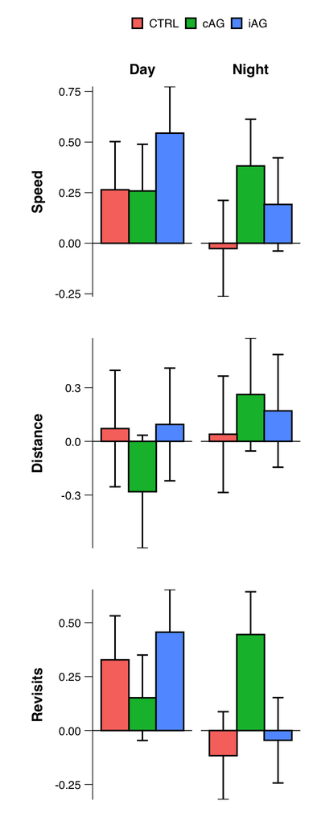

## Create Combined plot

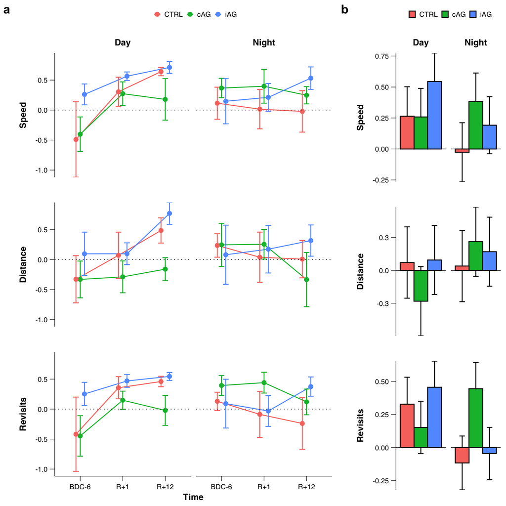

```r
# Combine plot
p.navis_vr_comb <- plot_grid(p.navis_vr_desc, p.navis_vr_emmeans_main + rremove("x.text") + theme(legend.key.size = unit(0.3, 'cm')),
          labels = c("a", "b"),
          ncol = 2, nrow = 1,
          rel_widths = c(2, 1))

p.navis_vr_comb <- p.navis_vr_comb + theme(legend.key.size = unit(0.3, 'cm'))

# Save plot as pdf
pdf("./Figures/Spatial Cognition 2/p.navis_vr_comb.pdf",
    width = 30/2.54,
    height = 20/2.54,
    useDingbats = FALSE) #in cm
print(p.navis_vr_comb)
dev.off()
```